# Data Visualization in R (Light Focus)

## Adding Annotations and Custom Geometries

Annotations and custom geometries enhance plots by adding text annotations, lines, or other shapes to highlight specific features or data points.

### Annotations

Adding text annotations to highlight specific points or areas on the plot.

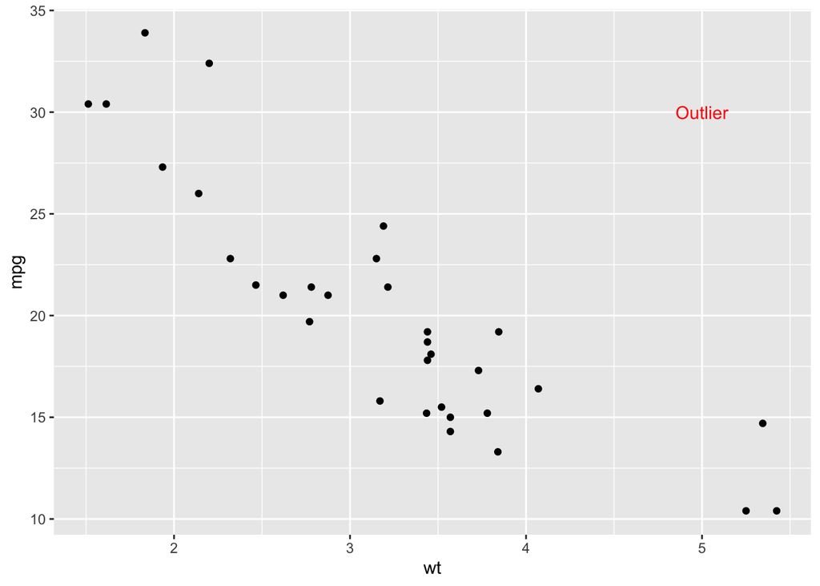

```r
# Example of adding annotations
ggplot(mtcars, aes(x = wt, y = mpg)) +
  geom_point() +
  annotate("text", x = 5, y = 30, label = "Outlier", color = "red")
```

### Custom Geometries

You can draw shapes or lines to highlight trends or important areas.

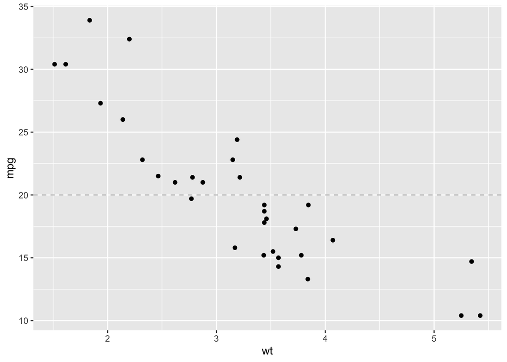

```r
# Example of adding custom geometries
ggplot(mtcars, aes(x = wt, y = mpg)) +
  geom_point() +
  geom_hline(yintercept = 20, linetype = "dashed", color = "gray")
```

These customization techniques in ggplot2 enable you to tailor your visualizations precisely to your data’s narrative, improving not only the aesthetics but also the effectiveness of your data presentations.

## Interactive Demonstrations

Let’s illustrate these concepts with interactive examples. Try running these scripts in your R environment to see how `ggplot2` brings your data to life.

### Interactive Example: Creating a Scatter Plot

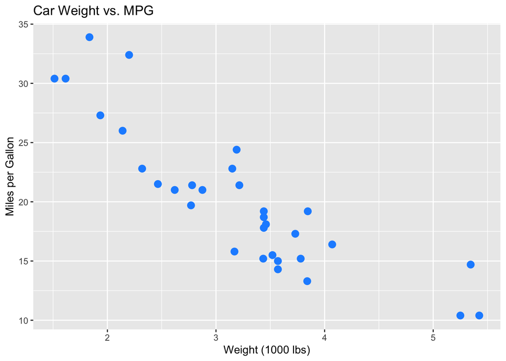

```r
library(ggplot2)

# Creating a scatter plot of mpg vs wt
scatter_plot <- ggplot(mtcars, aes(x = wt, y = mpg)) +
  geom_point(size = 3, color = "dodgerblue") +
  labs(title = "Car Weight vs. MPG", x = "Weight (1000 lbs)", y = "Miles per Gallon")
print(scatter_plot)
```

### Interactive Example: Customizing a Scatter Plot

[figure not shown]

```r
# Enhancing scatter plot with themes and labels
enhanced_scatter_plot <- ggplot(mtcars, aes(x = wt, y = mpg, color = cyl)) +  # Color points by cylinder count
  geom_point(size = 4) +
  labs(title = "Car Weight vs. MPG",
       x = "Weight (1000 lbs)",
       y = "Miles per Gallon",
       color = "Number of Cylinders") +
  theme_minimal()  # Using a minimal theme
print(enhanced_scatter_plot)
```

### Interactive Example: Adding Annotations and Custom Geometries

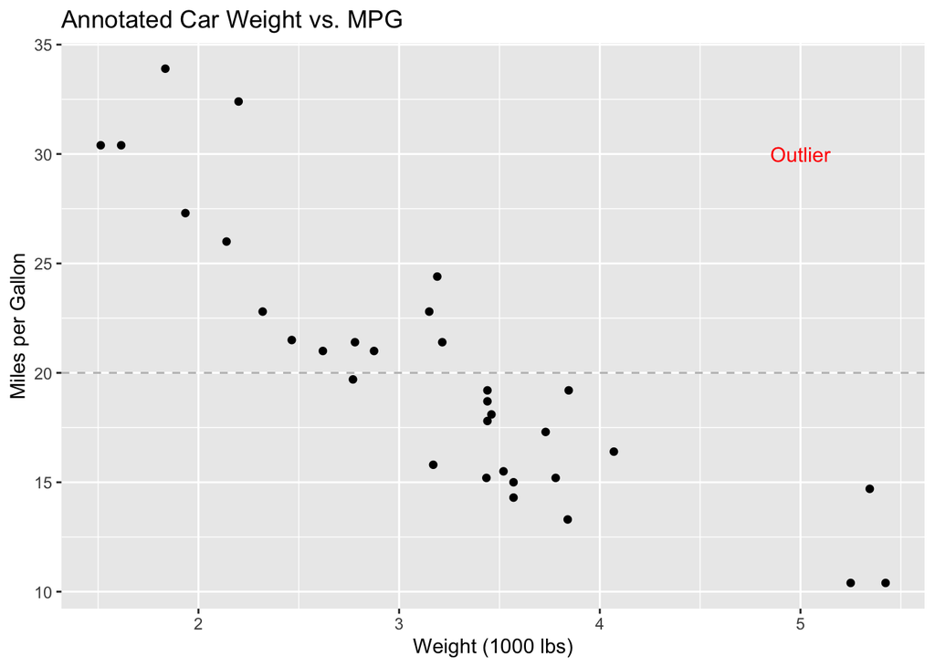

```r
# Adding annotations and custom geometries to a scatter plot
annotated_plot <- ggplot(mtcars, aes(x = wt, y = mpg)) +
  geom_point() +
  geom_hline(yintercept = 20, linetype = "dashed", color = "gray") +
  annotate("text", x = 5, y = 30, label = "Outlier", color = "red") +
  labs(title = "Annotated Car Weight vs. MPG",
       x = "Weight (1000 lbs)",
       y = "Miles per Gallon")
print(annotated_plot)
```

By running these interactive examples, you will gain a deeper understanding of how to leverage `ggplot2` for creating effective and visually appealing data visualizations in R.